# Pileup Plots, for Ssd1 analysis

Edward Wallace

17 Oct 2020

## Summary

Pileup plots for Ssd1 CRAC data, only on specific regions of specific Ssd1 target genes that are specified in `input_annotation/Ssd1TargetGeneNamesOnly.txt`. These show detailed profiles of read counts, including nucleotide-specific mutations and deletions, along selected transcripts. Search for instances of the `CNYUCNYU` Ssd1-associated motif in those transcripts, and the `CCAACU` upstream motif.

This script relies on “pileup” files in tab-separated text format produced by `pyPileup` script while running the pipeline, put in the directory `/Ssd1_CRAC_demult_dedup_20190114_all/pyPileup_analyses/`. So it must be run after `src/CRAC_pipeline_SE_demult_dedup.py`, see the repository `README.md` for details.

## Functions for data loading and plotting

```r
read_pileuptxt <- function(file,converturidine=FALSE) {
    pileupdf <- readr::read_tsv(file = file,
                    comment = "#",
                    col_types = "cifiii",
                    col_names = c("target","position","nucleotide",
                                  "hits","substitutions","deletions")
    )
    if (converturidine) {
        pileupdf <- mutate(pileupdf,
                           nucleotide = fct_recode(nucleotide, U = "T") )
    }
    pileupdf
}

scale_fill_pileup <- function(...) {
    scale_fill_manual(values = c(aligned = "grey50",
                                 substitutions = "black",
                                 deletions = "red2"),
                      ...)
}

plot_pileup_one <- function(pileupdf,
                            include = "allonly",
                            nucseq = FALSE,
                            nuctxtsize = 2.8) {
    p_pileup <- ggplot(data = pileupdf, aes(x=position)) +
        coord_cartesian(expand = FALSE, clip = "off")
    if (include == "allonly") {
        p_pileup <- p_pileup +
            geom_col(aes(y = hits))
    } else if (include == "allsub") {
        p_pileup <- p_pileup +
            geom_col(aes(y = hits,
                         fill = "aligned")) +
            geom_col(aes(y = substitutions,
                         fill = "substitutions"))
    } else if (include == "alldel") {
        p_pileup <- p_pileup +
            geom_col(aes(y = hits,
                         fill = "aligned")) +
            geom_col(aes(y = deletions,
                         fill = "deletions"))
    } else if (include == "allsubdel") {
        # this is a hack that prints substitutions behind deletions
        # so that total height is added, it looks "stacked".
        # There would be a better way of doing it with reshaping and
        # position = "stack".
        p_pileup <- p_pileup +
            geom_col(aes(y = hits,
                         fill = "aligned"))  +
            geom_col(aes(y = substitutions + deletions,
                         fill = "substitutions")) +
            geom_col(aes(y = deletions,
                         fill = "deletions"))  +
            scale_fill_pileup("Hit type")
    }

    if (nucseq) {
        p_pileup <- p_pileup +
            geom_text(aes(label = nucleotide),
                      y = 0, family = 'Courier', vjust = 1.1,
                      size = nuctxtsize) +
            theme(axis.title.x =  element_blank(),
                  axis.line.x = element_blank(),
                  axis.text.x = element_blank(),
                  axis.ticks.x = element_blank()) +
            expand_limits(y = - max(pileupdf$hits / 16 ) )
    }
    p_pileup
}

plot_pileuphits_line <- function(pileupdf) {
    ggplot(data = pileupdf,
           aes(x=position, y = hits)) +
        coord_cartesian(expand = FALSE) +
        geom_line(aes(y = hits))
}

plot_nucseq <- function(nucdf) {
    # fix the width
    ggplot(data = nucdf, aes(x = position, label = nucleotide) ) +
        geom_text(y=0,family='Courier') +
        theme_nothing()
}

position_locate_all <- function(posdf,
                                pattern = "C[ACUG][CU]UC[ACUG][CU]U") {
    posdf$nucleotide %>%
        as.character() %>%
        paste(collapse = "") %>%
        stringr::str_locate_all(pattern) %>%
        .[[1]]
}

SEE_colour    <- "#2b9744"
CCAACU_colour <- "#3fa6b0"

geom_motifhighlightpt <- function(...) {
    geom_point(y=0, aes(x=mid), colour = SEE_colour, size = 3, shape = 17, vjust = 1,
               ...)
}

annotate_motifhighlightsegment <- function(mid,halfwidth=3.5) {
    annotate(y=0, yend = 0, x = mid-halfwidth, xend=mid+halfwidth,
             geom="segment", colour = SEE_colour, size = 2)
}

annotate_motifhighlight <- function(mid,...) {
    annotate(geom="text", size = 3, y = 0, x = mid, vjust = 0.9, fontface = "bold",
             ...)
}

annotate_SEE <- function(mid, ...) {
    annotate_motifhighlight(mid, label = "m", colour = SEE_colour, ...)
}

annotate_CCAACU <- function(mid, ...) {
    annotate_motifhighlight(mid, label = "u", colour = CCAACU_colour, ...)
}
```

## Load just one data set for example analysis

```r
# setwd("~/Repos/Ssd1_CRACanalysis_2020/rmarkdown")

Ssd1_3_30_df <- read_pileuptxt("../Ssd1_CRAC_demult_dedup_20190114_all/pyPileup_analyses/20190114_Ssd1_CRAC_trimmed_NNNGTGAGC_SSD1_3_30_pileups.txt",converturidine = TRUE)
```

## Plot pileup along SUN4 transcript as a line

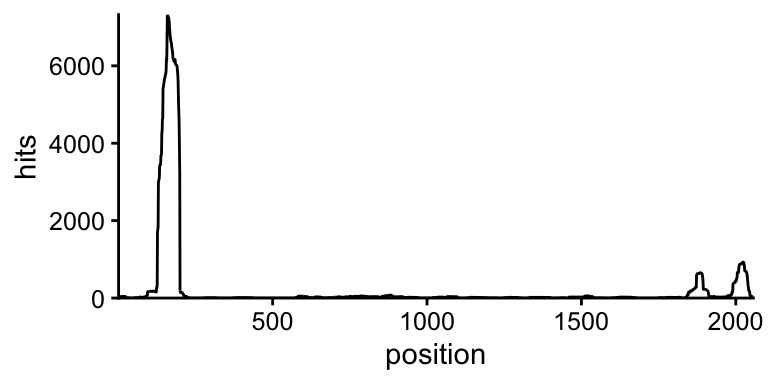

```r
plot_pileuphits_line(filter(Ssd1_3_30_df, target == "SUN4") )
```

## Plot pileup focus on peaks SUN4 5’UTR

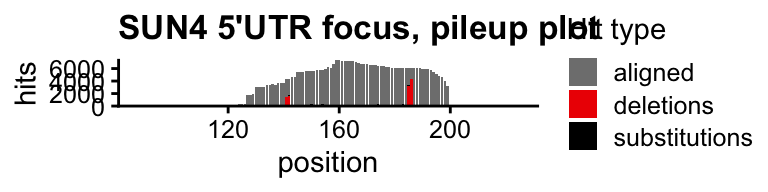

```r
SUN4_5UTRwide_df <- filter(Ssd1_3_30_df,
                         target == "SUN4",
                         position >= 81,
                         position <= 231)

SUN4_5UTRwide_plot <- plot_pileup_one(SUN4_5UTRwide_df, include = "allsubdel") +
    labs(title = "SUN4 5'UTR focus, pileup plot")
SUN4_5UTRwide_plot
```

## Plot pileup focus on SUN4 5’UTR, restricted to “SUN4_duo” vicinity

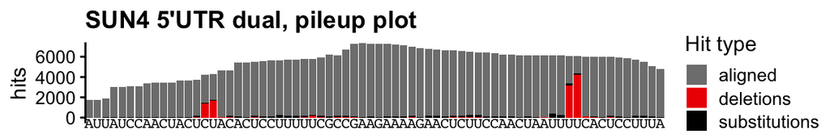

```r
SUN4dual_df <- filter(Ssd1_3_30_df,
                      target == "SUN4",
                      position >= 127,
                      position <= 196)

SUN4_5dual_plot <- plot_pileup_one(SUN4dual_df,
                                   include = "allsubdel",
                                   nucseq = TRUE) +
    labs(title = "SUN4 5'UTR dual, pileup plot")
SUN4_5dual_plot
```

```r
ggsave(plot = SUN4_5dual_plot, filename = "../figure_out/SUN4_5dual_3_30_plot.pdf",
       height = 1, width=6, device = "pdf")
```

## Plot pileups centred only on Ssd1-enriched motifs

Plot pileup on same area surrounding the SEE motifs (-12, +2) to look for consistent location of crosslinking sites.

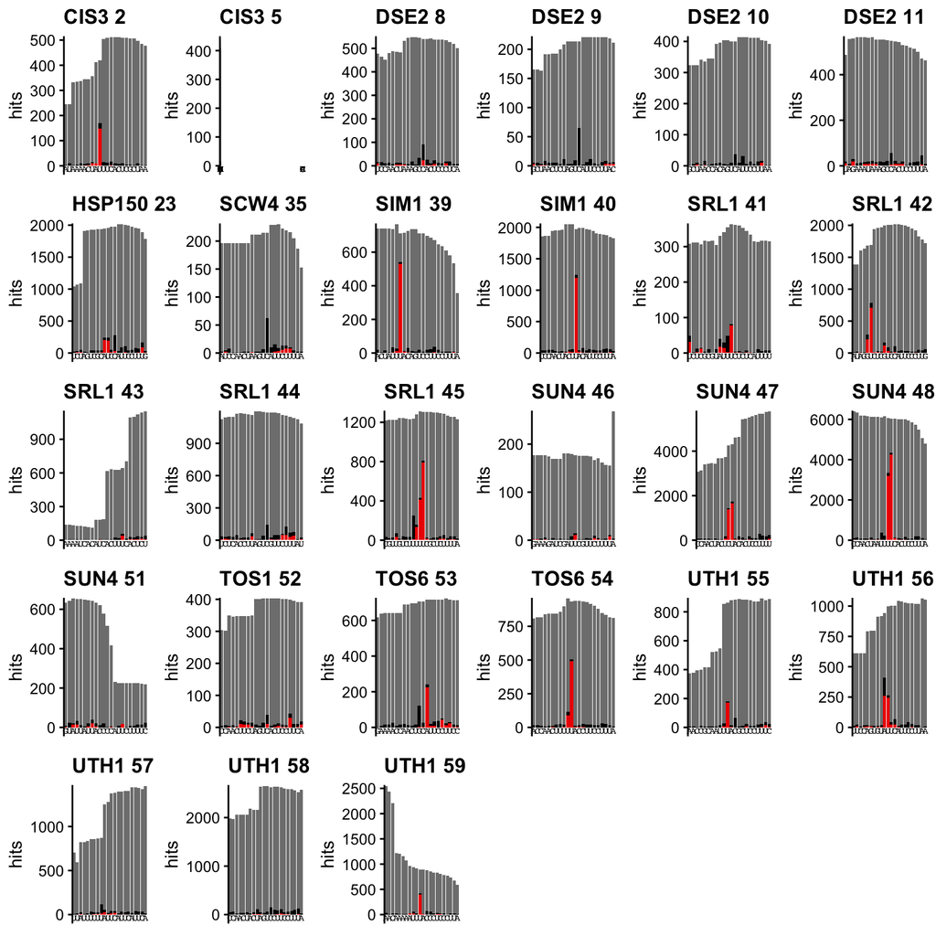

```r
SEE_positions_all <- position_locate_all(Ssd1_3_30_df) %>%
    as_tibble() %>%
    mutate(motifid = 1:nrow(.))

get_chunk <- function(sedf,datadf) {
    datadf[sedf$start : sedf$end,]
}

SEE_motif_pileups <-
    SEE_positions_all[-1,] %>%
    mutate(start = start - 12, end=end + 2) %>%
    group_by(motifid) %>%
    do(get_chunk(., datadf = Ssd1_3_30_df)) %>%
    mutate(motifidg = paste(target, motifid),
           maxhits = max(hits)) %>%
    filter(maxhits > 150)

SEE_motif_pileups %>%
    do(plot = plot_pileup_one(.,include = "allsubdel",
                              nucseq = TRUE,nuctxtsize = 2) +
        theme(legend.position = "none") +
           labs(title = .$motifidg[1])) %>%
    .$plot %>%
    plot_grid(plotlist = .)
```

```r
# SEE_motifs
```

We are likely to detect crosslinking by apparent deletions in U-rich regions 1-4nt upstream of CNYUCNYU. However, because these are often U(4), or in some cases (CU)(2), the data do not tell us exactly which nucleotide position is crosslinked.

## Find SEE motif positions separately for each transcript

```r
SEE_positions_bytx <- Ssd1_3_30_df %>%
    group_by(target) %>%
    do(., position_locate_all(.) %>% as_tibble() ) %>%
    mutate(mid = start + 3.5)
SEE_positions_bytx
```

```
## # A tibble: 60 x 4
## # Groups:   target [16]
##    target start   end   mid
##    <chr>  <int> <int> <dbl>
##  1 CCW12     34    41  37.5
##  2 CIS3      30    37  33.5
##  3 CIS3     700   707 704.
##  4 CIS3     984   991 988.
##  5 CTS1       5    12   8.5
##  6 DSE2      56    63  59.5
##  7 DSE2     197   204 200.
##  8 DSE2     326   333 330.
##  9 DSE2     386   393 390.
## 10 DSE2     435   442 438.
## # … with 50 more rows
```

```r
CCAACU_positions_bytx <- Ssd1_3_30_df %>%
    group_by(target) %>%
    do(., position_locate_all(.,pattern = "CCAACU") %>% as_tibble() ) %>%
    mutate(mid = start + 2.5)
CCAACU_positions_bytx
```

```
## # A tibble: 22 x 4
## # Groups:   target [13]
##    target start   end   mid
##    <chr>  <int> <int> <dbl>
##  1 CCW12    365   370  368.
##  2 CTS1    1081  1086 1084.
##  3 DSE2     315   320  318.
##  4 DSE2    1018  1023 1020.
##  5 HSL1     328   333  330.
##  6 LRE1     213   218  216.
##  7 LRE1     492   497  494.
##  8 MMR1     309   314  312.
##  9 MMR1    1814  1819 1816.
## 10 MMR1    1873  1878 1876.
## # … with 12 more rows
```

## Load pileup data from all four Ssd1 CRAC samples

```r
# setwd("Downloads/pyPileup_analyses/")

data_dir <- "../Ssd1_CRAC_demult_dedup_20190114_all/pyPileup_analyses/"
Ssd1_allsamples_df <-
    bind_rows(
        read_pileuptxt(paste0(data_dir,
                              "20190114_Ssd1_CRAC_trimmed_NNNGTGAGC_SSD1_3_30_pileups.txt"),
                       converturidine = TRUE) %>%
            mutate(Sample="3_30",Temperature="30C",BioRep = "A"),
        read_pileuptxt(paste0(data_dir,
                              "20190114_Ssd1_CRAC_trimmed_NNNTGGAGC_SSD1_4_30_pileups.txt"),
                       converturidine = TRUE)  %>%
            mutate(Sample="4_30",Temperature="30C",BioRep = "B"),
        read_pileuptxt(paste0(data_dir,
                              "20190114_Ssd1_CRAC_trimmed_NNNAGAGC_SSD1_3_42_pileups.txt"),
                       converturidine = TRUE) %>%
            mutate(Sample="3_42",Temperature="42C",BioRep = "A"),
        read_pileuptxt(paste0(data_dir,
                              "20190114_Ssd1_CRAC_trimmed_NNNCTAGC_SSD1_4_42_pileups.txt"),
                       converturidine = TRUE)  %>%
            mutate(Sample="4_42",Temperature="42C",BioRep = "B")
    ) %>%
    mutate(SampleNice = paste(Temperature,"Rep.", BioRep))

Ssd1_allsamples_df
```

```
## # A tibble: 115,408 x 10
##    target position nucleotide  hits substitutions deletions Sample Temperature
##    <chr>     <int> <fct>      <int>         <int>     <int> <chr>  <chr>
##  1 CCW12         1 C              0             0         0 3_30   30C
##  2 CCW12         2 U              0             0         0 3_30   30C
##  3 CCW12         3 U              0             0         0 3_30   30C
##  4 CCW12         4 U              0             0         0 3_30   30C
##  5 CCW12         5 C              0             0         0 3_30   30C
##  6 CCW12         6 C              0             0         0 3_30   30C
##  7 CCW12         7 U              0             0         0 3_30   30C
##  8 CCW12         8 A              0             0         0 3_30   30C
##  9 CCW12         9 A              0             0         0 3_30   30C
## 10 CCW12        10 C              0             0         0 3_30   30C
## # … with 115,398 more rows, and 2 more variables: BioRep <chr>,
## #   SampleNice <chr>
```

## Plot pileup on SUN4 5’UTR to show reproducibility

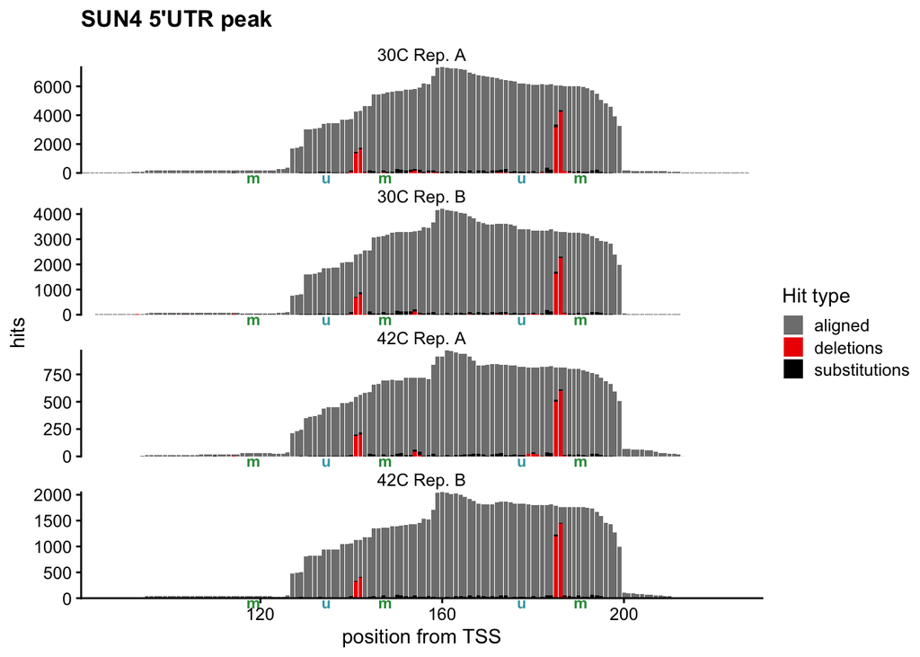

```r
SUN4_5UTRwiderep_df <- filter(Ssd1_allsamples_df,
                         target == "SUN4",
                         position >= 81,
                         position <= 230)

SUN4_5UTRwiderep_plot <-
    plot_pileup_one(SUN4_5UTRwiderep_df, include = "allsubdel") +
    facet_wrap(~SampleNice, ncol = 1, scales = "free_y") +
    labs(title = "SUN4 5'UTR peak", x = "position from TSS")  +
    annotate_SEE(filter(SEE_positions_bytx,target=="SUN4",mid < 230)$mid) +
    annotate_CCAACU(filter(CCAACU_positions_bytx,target=="SUN4",mid < 230)$mid)
SUN4_5UTRwiderep_plot
```

```r
# ggsave(plot = SUN4_5UTRwiderep_plot,
#        filename = "SUN4_5dual_reproducible_plot.pdf",
#        height = 4, width = 6, device = "pdf")
```

## Plot pileup on UTH1 5’UTR to show reproducibility

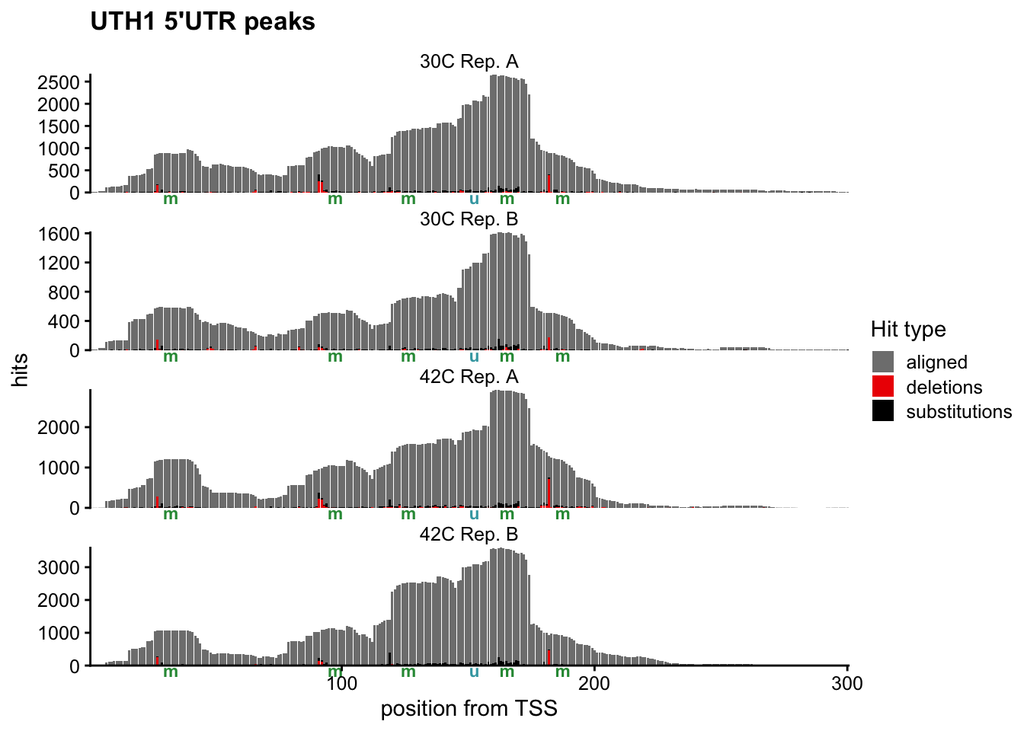

```r
UTH1_5UTRwiderep_df <- filter(Ssd1_allsamples_df,
                         target == "UTH1",
                         position >= 1,
                         position <= 300)

UTH1_5UTRwiderep_plot <-
    plot_pileup_one(UTH1_5UTRwiderep_df, include = "allsubdel") +
    facet_wrap(~SampleNice, ncol = 1, scales = "free_y") +
    labs(title = "UTH1 5'UTR peaks", x = "position from TSS") +
    annotate_SEE(filter(SEE_positions_bytx,target=="UTH1",mid < 300)$mid) +
    annotate_CCAACU(filter(CCAACU_positions_bytx,target=="UTH1",mid < 300)$mid)
UTH1_5UTRwiderep_plot
```

```r
# ggsave(plot = UTH1_5UTRwiderep_plot,
#        filename = "UTH1_5wide_reproducible_plot.pdf",
#        height = 4, width = 6, device = "pdf")
```

## Plot focused on UTH1 CNYUCNYU vicinity

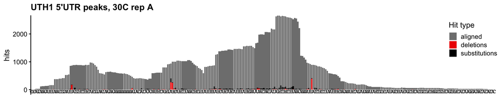

```r
UTH1_5UTRwideone_plot <-
    filter(UTH1_5UTRwiderep_df, Sample == "3_30" ) %>%
    plot_pileup_one(include = "allsubdel",nucseq = TRUE) +
    labs(title = "UTH1 5'UTR peaks, 30C rep A", x = "position from TSS") +
    theme(legend.position = c(0.9,0.7))
UTH1_5UTRwideone_plot
```

```r
# ggsave(plot = UTH1_5UTRwideone_plot,
#        filename = "UTH1_5wide_3_30_plot.pdf",
#        height = 2, width = 12, device = "pdf")
```

## Plot pileup on SRL1 5’UTR to show reproducibility

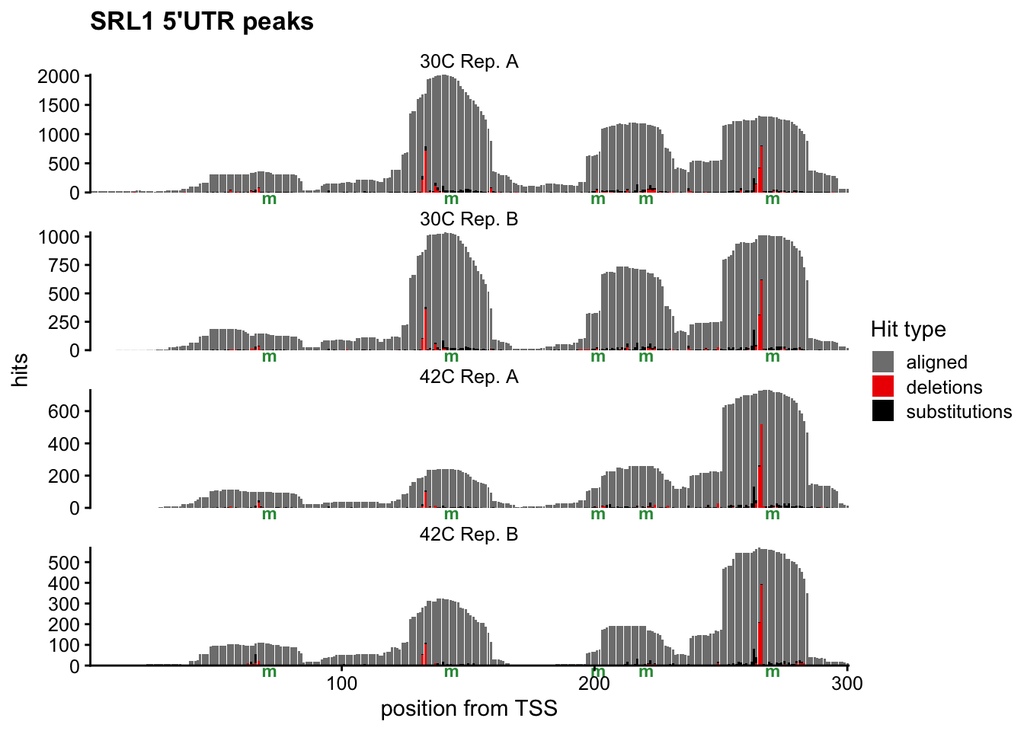

```r
SRL1_5UTRwiderep_df <- filter(Ssd1_allsamples_df,
                         target == "SRL1",
                         position >= 1,
                         position <= 300)

SRL1_5UTRwiderep_plot <-
    plot_pileup_one(SRL1_5UTRwiderep_df, include = "allsubdel") +
    facet_wrap(~SampleNice, ncol = 1, scales = "free_y") +
    labs(title = "SRL1 5'UTR peaks", x = "position from TSS") +
    annotate_SEE(filter(SEE_positions_bytx,target=="SRL1",mid < 300)$mid) +
    annotate_CCAACU(filter(CCAACU_positions_bytx,target=="SRL1",mid < 300)$mid)
SRL1_5UTRwiderep_plot
```

```r
# ggsave(plot = SRL1_5UTRwiderep_plot,
#        filename = "SRL1_5wide_reproducible_plot.pdf",
#        height = 4, width = 6, device = "pdf")
```

## Plot focused on SRL1 CNYUCNYU vicinities - there are two

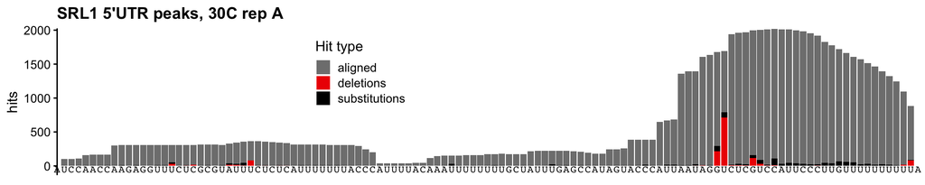

```r
SRL1_5UTRupone_plot <-
    filter(SRL1_5UTRwiderep_df, Sample == "3_30" ) %>%
    plot_pileup_one(include = "allsubdel",nucseq = TRUE) +
    xlim(40,160) +
    labs(title = "SRL1 5'UTR peaks, 30C rep A", x = "position from TSS") +
    theme(legend.position = c(0.3,0.7))
SRL1_5UTRupone_plot
```

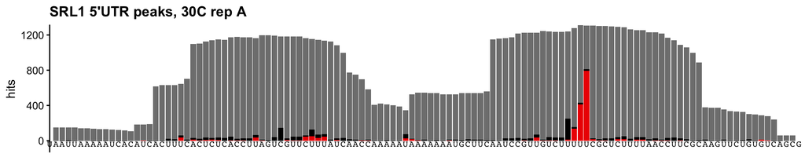

```r
SRL1_5UTRdownone_plot <-
    filter(SRL1_5UTRwiderep_df, Sample == "3_30" ) %>%
    plot_pileup_one(include = "allsubdel",nucseq = TRUE) +
    xlim(180,300) +
    labs(title = "SRL1 5'UTR peaks, 30C rep A", x = "position from TSS") +
    theme(legend.position = "none")
SRL1_5UTRdownone_plot
```

## Plot pileup on CCW12 5’UTR to show reproducibility

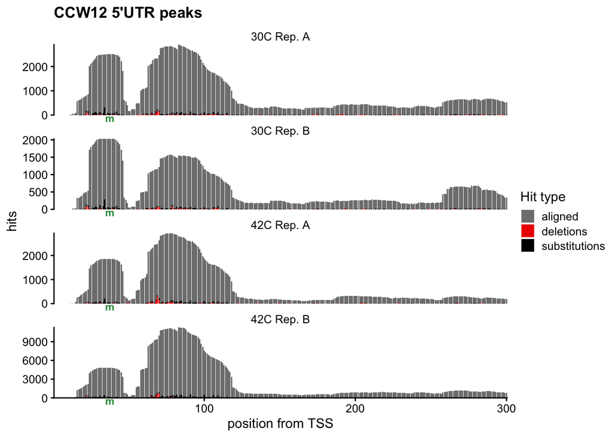

```r
CCW12_5UTRwiderep_df <- filter(Ssd1_allsamples_df,
                         target == "CCW12",
                         position >= 1,
                         position <= 300)

CCW12_5UTRwiderep_plot <-
    plot_pileup_one(CCW12_5UTRwiderep_df, include = "allsubdel") +
    facet_wrap(~SampleNice, ncol = 1, scales = "free_y") +
    labs(title = "CCW12 5'UTR peaks", x = "position from TSS") +
    annotate_SEE(filter(SEE_positions_bytx,target=="CCW12",mid < 250)$mid) +
    annotate_CCAACU(filter(CCAACU_positions_bytx,target=="CCW12",mid < 300)$mid)
CCW12_5UTRwiderep_plot
```

```r
# ggsave(plot = CCW12_5UTRwiderep_plot,
#        filename = "CCW12_5wide_reproducible_plot.pdf",
#        height = 4, width = 6, device = "pdf")
```

## Plot pileup on SCW4 5’UTR to show reproducibility

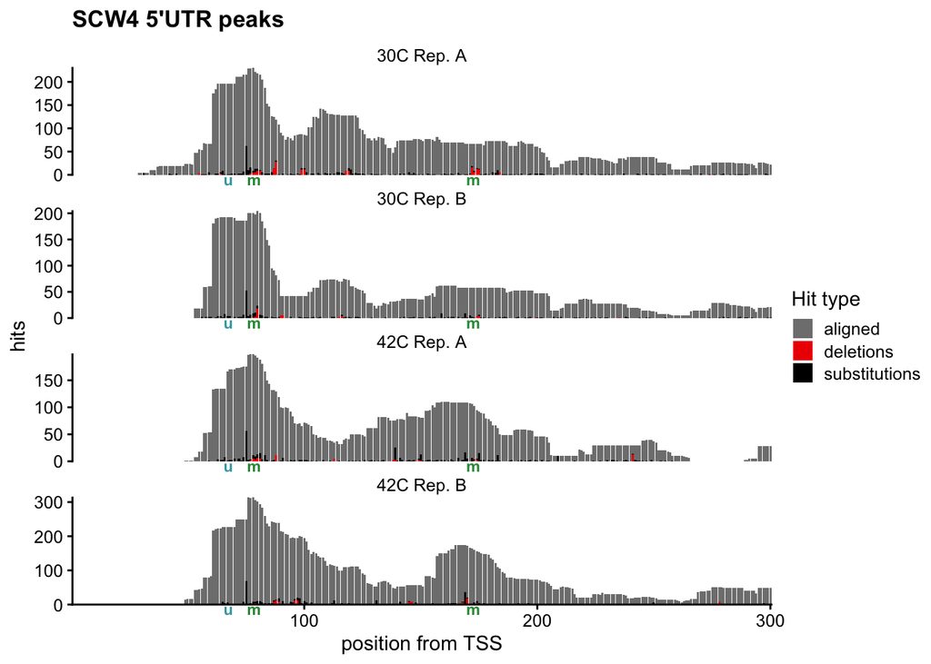

```r
SCW4_5UTRwiderep_df <- filter(Ssd1_allsamples_df,
                         target == "SCW4",
                         position >= 1,
                         position <= 300)

SCW4_5UTRwiderep_plot <-
    plot_pileup_one(SCW4_5UTRwiderep_df, include = "allsubdel") +
    facet_wrap(~SampleNice, ncol = 1, scales = "free_y") +
    labs(title = "SCW4 5'UTR peaks", x = "position from TSS") +
    annotate_SEE(filter(SEE_positions_bytx,target=="SCW4",mid < 250)$mid) +
    annotate_CCAACU(filter(CCAACU_positions_bytx,target=="SCW4",mid < 300)$mid)
SCW4_5UTRwiderep_plot
```

```r
# ggsave(plot = SCW4_5UTRwiderep_plot,
#        filename = "SCW4_5wide_reproducible_plot.pdf",
#        height = 4, width = 6, device = "pdf")
```

## Composite plot - Supplementary figure of manuscript

Output to `/figure_out/Ssd1_pileup_plot_reproducible_4genes.pdf`.

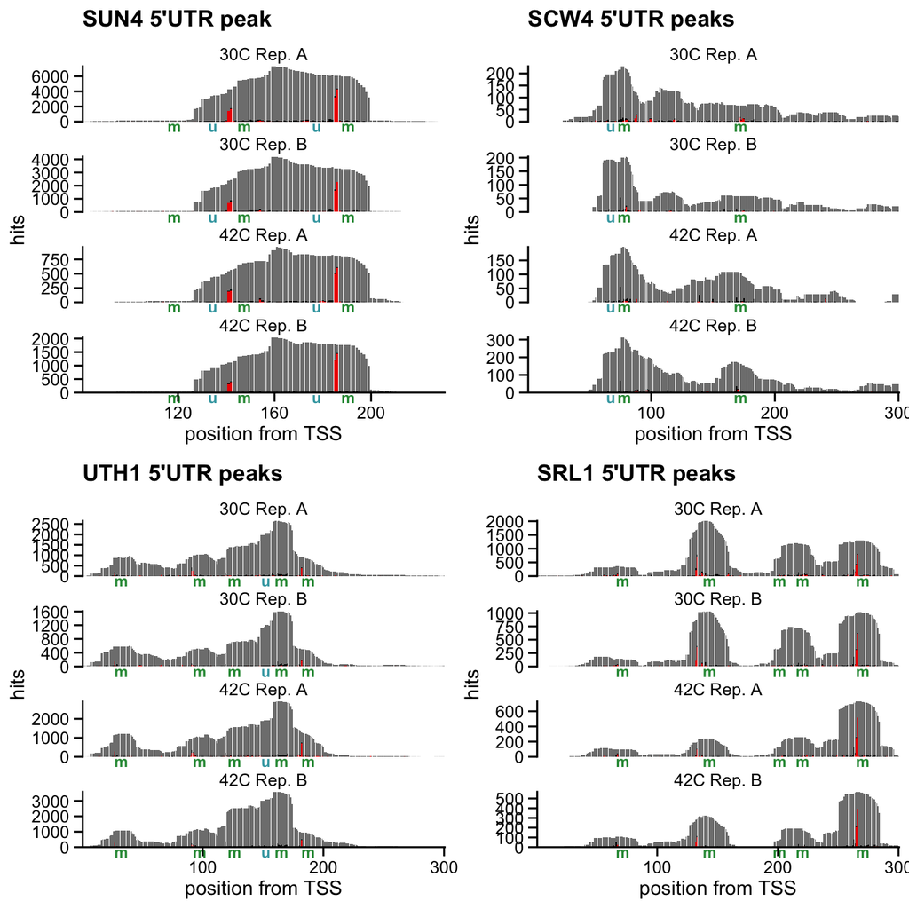

```r
theme_5UTR_grid <-  theme(legend.position="none",
                          axis.ticks.length = unit(5,"pt") )
pileup_plot_reproducible_4genes <-
    plot_grid(SUN4_5UTRwiderep_plot + theme_5UTR_grid,
          SCW4_5UTRwiderep_plot + theme_5UTR_grid,
          UTH1_5UTRwiderep_plot + theme_5UTR_grid,
          SRL1_5UTRwiderep_plot + theme_5UTR_grid
          )
pileup_plot_reproducible_4genes
```

```r
ggsave(plot = pileup_plot_reproducible_4genes,
       filename = "../figure_out/Ssd1_pileup_plot_reproducible_4genes.pdf",
       height = 7, width = 7, device = "pdf")
```